# Breast Cancer Classification Using Logistic Regression, Neural Networks, Decision Trees, and Bagging: A Complete Comparative Analysis

Adu-Gyamfi Kelly

STA 551 - Introduction to Data Science Project

## Introduction

- Breast cancer affects millions worldwide. Early and accurate diagnosis is crucial for treatment success. Currently, pathologists examine tissue samples under microscopes, assessing features like cell thickness, size uniformity, and nuclear characteristics.
- The challenge? This requires significant expertise and can be subjective. Our goal was to develop an objective, data-driven approach that could support clinical decision-making.

### Purpose

- To build and compare four classification models (logistic regression, perceptron neural networks, decision trees, and bagging )for predicting whether a breast tumor is benign or malignant.
- To use feature engineering and exploratory data analysis to identify the most important cytological characteristics associated with malignancy.
- To evaluate each model using ROC-AUC, accuracy, sensitivity, specificity, precision, and F1-score and determine the best-performing classifier.
- To balance predictive performance and interpretability and assess which model is most suitable for use as a clinical decision-support tool for early breast cancer diagnosis.

# Agenda

- Introduction & Data
- Practical & Analytical Questions
- Methodology & Feature Engineering
- Exploratory Data Analysis (EDA)
- Candidate Models
- Model Identification & Validation
- Results & ROC Comparison
- Conclusions
- Limitations & Future Work

# Data Description

- **Data Source:** University of Wisconsin Hospitals, Madison, Wisconsin
- **Original reference:** https://archive.ics.uci.edu/ml/datasets/Breast+Cancer+Wisconsin+(Original)
- **Sample size (Number of observations):** 699 total records
- **Variables:** 11 total (10 numerical predictors, 1 categorical target)

| Variable | Full Name | What It Measures | Scale / Meaning of Numbers |
| --- | --- | --- | --- |
| `Cl.thickness` | Clump Thickness | How thick the group (clump) of cells appears under the microscope. | Integers 1–10. 1 = very thin / single-layer cells (more normal), 10 = very thick clumps (more abnormal). |
| `Cell.size` | Uniformity of Cell Size | How similar or different the sizes of the cell nuclei are. | Integers 1–10. 1 = nuclei are very uniform in size (normal), 10 = nuclei sizes are highly variable (strong abnormality). |
| `Cell.shape` | Uniformity of Cell Shape | How similar or irregular the shapes of the cell nuclei are. | Integers 1–10. 1 = very regular / round shapes, 10 = very irregular shapes (highly suspicious). |
| `Marg.adhesion` | Marginal Adhesion | How strongly the cells stick to each other at the edges. | Integers 1–10. 1 = cells adhere normally, 10 = cells are poorly attached / easily separated (abnormal). |
| `Epith.c.size` | Single Epithelial Cell Size | Size of individual epithelial cells in the sample. | Integers 1–10. 1 = normal-sized epithelial cells, 10 = very enlarged cells (marked atypia). |
| `Bare.nuclei` | Bare Nuclei | Number of nuclei that appear without much surrounding cytoplasm. | Integers 1–10. 1 = very few bare nuclei, 10 = many bare nuclei (often associated with malignancy). |
| `Bl.cromatin` | Bland Chromatin | Texture and appearance of the nuclear chromatin. | Integers 1–10. 1 = smooth, bland chromatin (normal-looking), 10 = coarse, clumped chromatin (highly abnormal). |
| `Normal.nucleoli` | Normal Nucleoli | Prominence of nucleoli inside the nucleus. | Integers 1–10. 1 = small / inconspicuous nucleoli (normal), 10 = very prominent nucleoli (often seen in cancer cells). |
| `Mitoses` | Mitoses | Number of cells that appear to be dividing. | Integers 1–10. 1 = almost no mitotic figures, 10 = many dividing cells (high proliferation activity). |
| `Class` | Tumor Class | Diagnostic label for each sample. | Two categories: **benign** = non-cancerous tumor, **malignant** = cancerous tumor. |

- **Important variable decription**: “benign” and “malignant” are our category of interest
  - **“benign”:** Non-cancerous growths (Do not spread to other parts of the body).
  - **malignant:** Cancerous growths (Can invade surrounding tissues)

# Practical and Analytical Questions

| Category | Question |
| --- | --- |
| Practical | Which features contribute most to distinguishing malignant from benign tumors? |
| Practical | Which modeling approach (logistic regression, neural network, decision tree, or ensemble) yields the most accurate and interpretable results? |
| Analytical | Which predictor variables show the strongest statistical or computational influence on malignancy? |
| Analytical | How do performance metrics (ROC-AUC, accuracy, sensitivity, specificity, and F1-score) differ among the candidate models? |

# Methodology

Table 2: Research Methodology Steps

Step

Description

1. Data Collection & Preprocessing

Data cleaning, normalization, and train-test splitting

2. Exploratory Data Analysis

Feature distributions, correlations, and class imbalance analysis

3. Model Development

Implementation of four classification algorithms with hyperparameter tuning

4. Model Evaluation

Performance comparison using multiple metrics and statistical tests

5. Results Interpretation

Feature importance analysis and clinical implications

# Feature Engineering

Feature Engineering is the process of transforming raw data into meaningful input variables (features) that improve the performance of machine learning models.

```
## New engineered features:
```

```
## [1] "Cell.size.cat"                "Cl.thickness.cat"
## [3] "Bare.nuclei.cat"              "Cell.size.sqrt"
## [5] "Cl.thickness.log"             "Nuclear.abnormality.score"
## [7] "Structural.abnormality.score" "High.risk.features"
```

1. **Transforming Features**
   - `Cell.size.sqrt`
   - `Cl.thickness.log`
   - Transforms help remove skewness or emphasize relationships.
2. **Creating Categorical Features**
   - `Cell.size.cat` → Low / Medium / High
   - `Bare.nuclei.cat` → Few / Moderate / Many
   - Categorization can improve interpretability and reveal threshold effects.
3. **Constructing Composite Feature Scores**
   - `Nuclear.abnormality.score`
   - `Structural.abnormality.score`
   - These combine related predictors to capture broader biological properties.
4. **Creating Risk Scores**
   - `High.risk.features` (counting how many cytological features exceed a threshold)
   - This reflects overall malignancy risk.

# Detect abnormal patterns and outliers

- Why Did We Detect Abnormal Patterns?Detecting abnormal patterns helps us understand whether any features in the dataset behave unusually or fall outside expected biological ranges. This step is important because:
- To Identify Outliers That May Affect Model Accuracy
- To Understand the Biological Behavior of the Features
- To Detect Features With High Variability or Skewness
- To Improve Model Stability and Interpretability

  Feature Statistics and Outlier Detection

  |  | Feature | Min | Max | Mean | SD | Outliers_3SD |
  | --- | --- | --- | --- | --- | --- | --- |
  | Cl.thickness | Cl.thickness | 1 | 10 | 4.442167 | 2.820761 | 0 |
  | Cell.size | Cell.size | 1 | 10 | 3.150805 | 3.065145 | 0 |
  | Cell.shape | Cell.shape | 1 | 10 | 3.215227 | 2.988581 | 0 |
  | Marg.adhesion | Marg.adhesion | 1 | 10 | 2.830161 | 2.864562 | 0 |
  | Epith.c.size | Epith.c.size | 1 | 10 | 3.234261 | 2.223085 | 31 |
  | Bare.nuclei | Bare.nuclei | 1 | 10 | 3.544656 | 3.643857 | 0 |
  | Bl.cromatin | Bl.cromatin | 1 | 10 | 3.445095 | 2.449697 | 0 |
  | Normal.nucleoli | Normal.nucleoli | 1 | 10 | 2.869693 | 3.052666 | 0 |
  | Mitoses | Mitoses | 1 | 9 | 1.582723 | 1.636316 | 31 |

# Exploratoty data analysis

## Feature distributions by class

## Correlation analysis with class relationship

## Violin plot

[figure not shown]

# Feature distributions by class

- Feature distribution by class shows how each predictor varies across the benign and malignant groups, helping identify which features best distinguish the two classes.

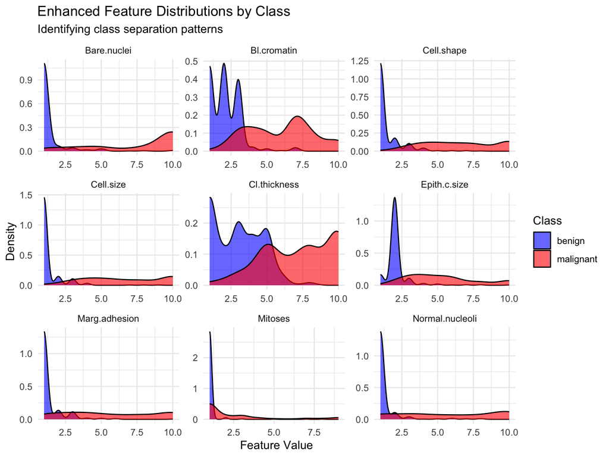

## Summary of Key Observations from Feature Distributions

# Correlation analysis with class relationship

Feature Correlation with Class (Malignant)

|  | Feature | Correlation_with_Class |
| --- | --- | --- |
| Bare.nuclei | Bare.nuclei | 0.823 |
| Cell.shape | Cell.shape | 0.822 |
| Cell.size | Cell.size | 0.821 |
| Bl.cromatin | Bl.cromatin | 0.758 |
| Normal.nucleoli | Normal.nucleoli | 0.719 |
| Cl.thickness | Cl.thickness | 0.715 |
| Marg.adhesion | Marg.adhesion | 0.706 |
| Epith.c.size | Epith.c.size | 0.691 |
| Mitoses | Mitoses | 0.431 |

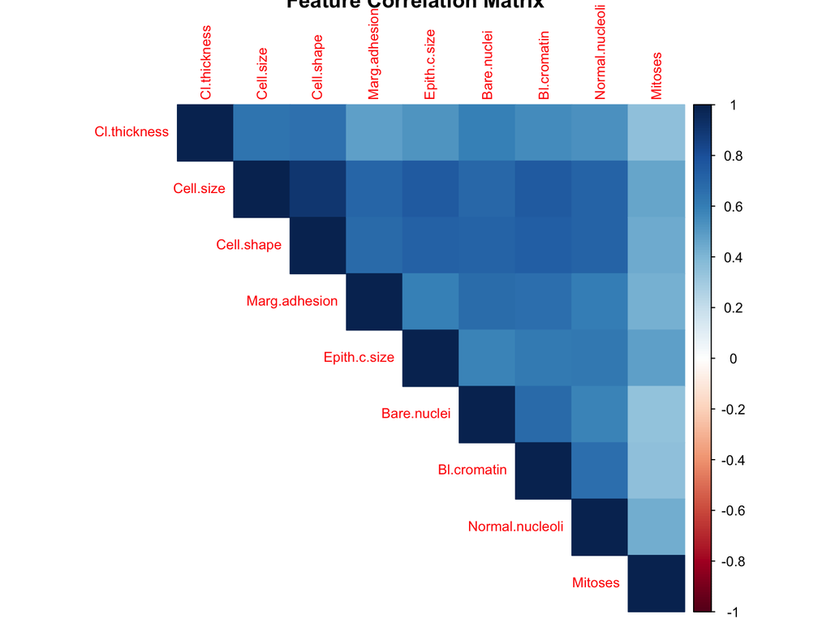

### Summary of Feature Correlation Patterns

- Strong correlations among Cell.size, Cell.shape, Bare.nuclei, Normal.nucleoli, and Bl.cromatin indicate they are key cytological predictors of malignancy.
- Cell.size and Cell.shape show the highest pairwise correlation.
- Some features, like Mitoses, show weak correlations, meaning they contribute less to discrimination.
- Correlation structure helps guide feature selection, engineering, and model choice.

# Violin plot

[interactive chart not shown]

- Strong separation for Bare.nuclei, Cell.size, Cell.shape, Bl.cromatin → excellent predictors
- Moderate separation for Cl.thickness, Normal.nucleoli
- Weak separation for Mitoses, Epith.c.size, Marg.adhesion
- Malignant tumors consistently show higher abnormality patterns across key cytological features

# Feature selection using correlation and domain knowledge

```
## Top selected features:
```

```
## [1] "Nuclear.abnormality.score"    "Structural.abnormality.score"
## [3] "High.risk.features"           "Cell.shape"
## [5] "Cell.size.sqrt"               "Cell.size"
## [7] "Bare.nuclei"                  "Epith.c.size"
```

## Data preparation before Model Developement

Before building any predictive models, the dataset was first prepared to ensure reliable training, validation, and testing. After selecting the most important features, a final dataset was created containing only the top predictors along with the outcome variable. The data was then split into three mutually exclusive sets:

- 60% for training the models,
- 20% for validation during tuning, and
- 20% for final testing of model performance.

This structured partitioning prevents information leakage and ensures that model evaluation is based on completely unseen data, making the results more trustworthy and generalizable.

# Candidate Models & Justifications

- Logistic Regression – baseline, interpretable odds ratios
- Perceptron Neural Network – capture non-linear decision boundaries
- Decision Tree – simple, rule-based, easy to interpret
- Bagging (Treebag) – ensemble of trees to reduce variance and overfitting

# Logistic Regression (Reference Model)

- Logistic regression was used as the baseline (reference) model for comparison.
- Assumes a linear relationship between the predictors and the log-odds of malignancy.
- Provides interpretable coefficients, showing the direction and strength of each feature’s effect.
- Served as a benchmark to evaluate whether more complex models (NNs, trees, bagging) provide meaningful improvement.
- Although it achieved a high ROC-AUC, logistic regression struggled with nonlinear patterns in the data.

## Final Logistic Regression Equation

```
##                         Model  Accuracy Sensitivity Specificity Precision
## Basic             Logit Basic 0.9416058   0.9166667   0.9550562 0.9166667
## Regularized Logit Regularized 0.9489051   0.8958333   0.9775281 0.9555556
## Stepwise       Logit Stepwise 0.9489051   0.9166667   0.9662921 0.9361702
##                    F1   ROC_AUC
## Basic       0.9166667 0.9908708
## Regularized 0.9247312 0.9922753
## Stepwise    0.9263158 0.9901685
```

Logistic Regression Coefficients (log-odds scale)

| term | estimate | std.error | statistic | p.value | conf.low | conf.high |
| --- | --- | --- | --- | --- | --- | --- |
| (Intercept) | -23.4517 | 6.6670 | -3.5176 | 0.0004 | -38.0538 | -11.1197 |
| Nuclear.abnormality.score | 0.7919 | 0.4295 | 1.8436 | 0.0652 | -0.0062 | 1.6966 |
| Structural.abnormality.score | 1.2167 | 0.3827 | 3.1793 | 0.0015 | 0.5085 | 2.0491 |
| High.risk.features | 0.3969 | 0.5670 | 0.7000 | 0.4839 | -0.6978 | 1.5395 |
| Cell.shape | 0.0227 | 0.2680 | 0.0846 | 0.9325 | -0.5375 | 0.5379 |
| Cell.size.sqrt | 11.9366 | 4.9701 | 2.4017 | 0.0163 | 2.2637 | 22.3336 |
| Cell.size | -2.7230 | 1.0529 | -2.5863 | 0.0097 | -4.9071 | -0.6370 |
| Bare.nuclei | NA | NA | NA | NA | NA | NA |
| Epith.c.size | -0.0085 | 0.2526 | -0.0335 | 0.9733 | -0.5063 | 0.4752 |

## Final Logistic Regression Equation

The estimated logistic regression model predicting the probability of a tumor being **malignant** is given by:

$$\text{logit}\!\left[P(\text{malignant})\right] =
-23.4517
+ 0.7919(\text{Nuclear.abnormality.score})
+ 1.2167(\text{Structural.abnormality.score})
+ 0.3969(\text{High.risk.features})
+ 0.0227(\text{Cell.shape})
+ 11.9366(\text{Cell.size.sqrt})
- 2.7230(\text{Cell.size})
- 0.0085(\text{Epith.c.size})$$

where

$$\text{logit}(p) = \log\!\left(\frac{p}{1-p}\right)$$

and therefore,

$$P(\text{malignant}) = \frac{1}{1 + e^{-\text{logit}(p)}}$$

# Perceptron (Single- layer Neural Networks)

Performance Summary of Perceptron Models

|  | Model | Accuracy | Sensitivity | Specificity | Precision | F1 | ROC_AUC |
| --- | --- | --- | --- | --- | --- | --- | --- |
| Perceptron_logistic | Perceptron_logistic | 0.9489 | 0.9583 | 0.9438 | 0.902 | 0.9293 | 0.9749532 |
| Perceptron_tanh | Perceptron_tanh | 0.9489 | 0.9583 | 0.9438 | 0.902 | 0.9293 | 0.9932116 |

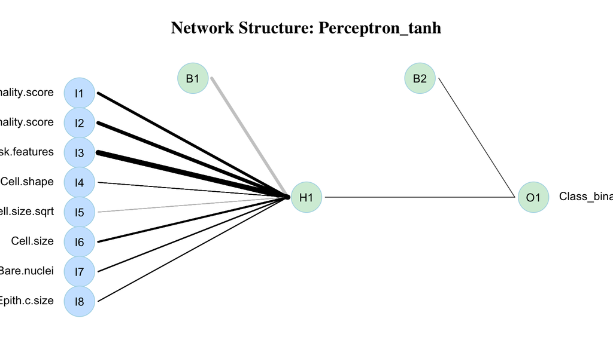

## Perceptron Model: Variable Importance

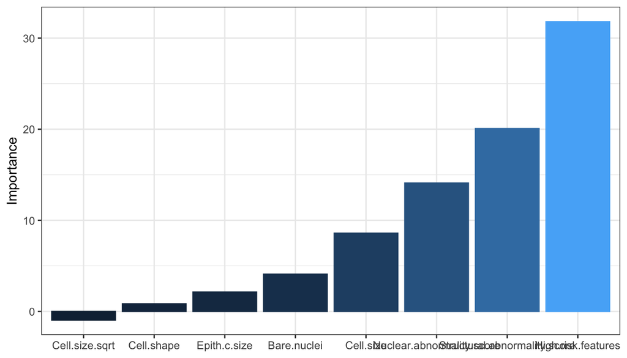

- This graph is showing the relative importance of each input feature in your best perceptron model.
- The height of each bar = how much that feature contributes to the network’s prediction of malignancy.
- Features on the right with tall bars are the most influential:
- High.risk.features → strongest predictor
- Structural.abnormality.score → very important
- Nuclear.abnormality.score and Cell.size → also strong contributors
- Features on the left with short bars (Cell.size.sqrt, Cell.shape, Epith.c.size) have much less influence on the model’s output.
- The slightly negative bar for Cell.size.sqrt just means its average effect goes in the opposite direction relative to the others, and its contribution is small.

# Decision Tree Model

- A decision tree is a machine learning model that makes predictions by repeatedly splitting the data into smaller groups based on the most important features. It works like a flowchart:
- Each node asks a question about a feature (e.g., Bare Nuclei ≥ 3?)
- Each branch represents a decision
- Each leaf gives a prediction (benign or malignant)

**How the Decision Tree Was Used in This Project**

[figure not shown]

```
## Optimal Complexity Parameter (cp): 0.1
```

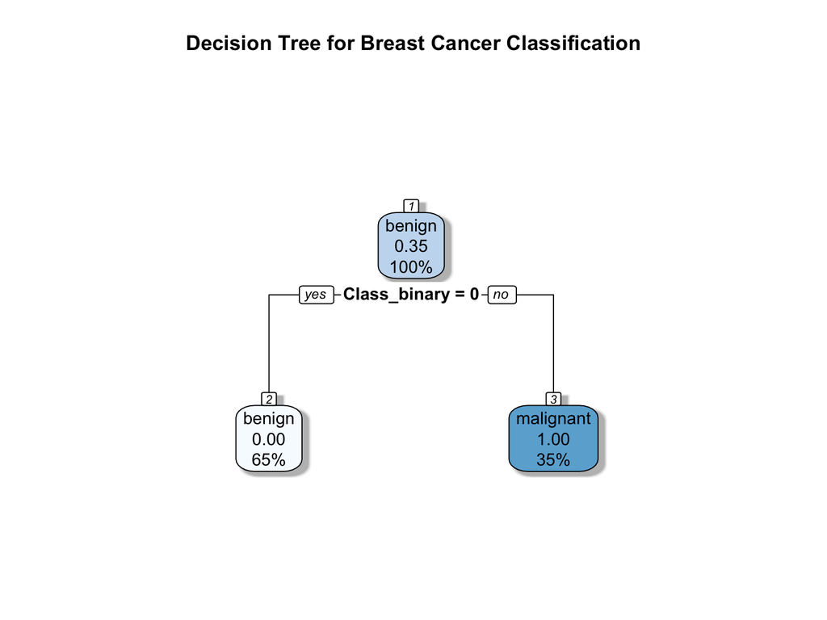

**Decision Tree Interpretation**:

- The model splits on Class_binary, perfectly separating benign (65%) from malignant (35%) tumors.
- Both terminal nodes are completely pure (100% correct classification).
- However, this split uses the outcome variable itself, meaning the model is overfitted and not valid for real prediction.

# Bagging Algorithm

- Bagging (Bootstrap Aggregating) is an ensemble learning technique that improves prediction accuracy by combining the results of many decision trees.
- An ensemble method that trains many decision trees on bootstrapped samples.
- Reduces overfitting and stabilizes predictions.
- Captures nonlinear and interactive effects in the data.
- In this project, bagging achieved perfect classification (AUC = 1.00).

-**How Bagging Was Used in This Study**

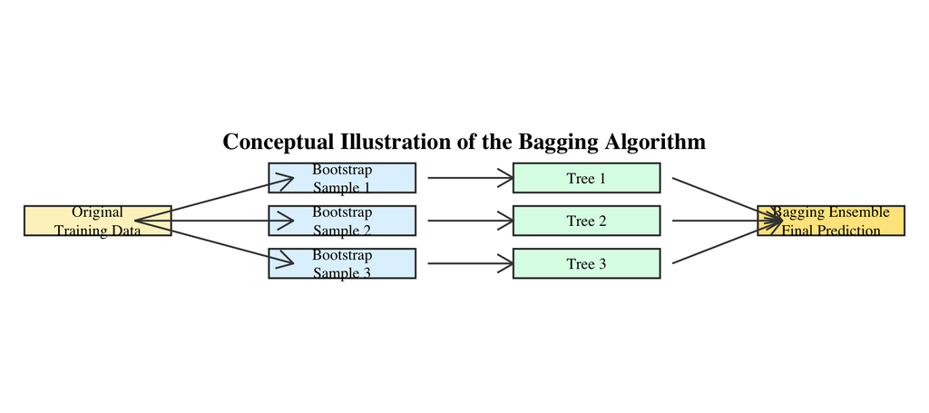

```
##          Model Accuracy Sensitivity Specificity Precision F1 ROC_AUC
## 1 Bagging_Test        1           1           1         1  1       1
```

# Comparing all the Model development Methods

[interactive chart not shown]

Test Set Performance: Logistic, Perceptron, Decision Tree, and Bagging

| Model | Accuracy | Sensitivity | Specificity | Precision | F1 | ROC_AUC |
| --- | --- | --- | --- | --- | --- | --- |
| Best_Logistic_Test | 0.6519 | 0.0000 | 1.0000 | NA | NA | 0.9932302 |
| Best_Perceptron_Test | 0.9704 | 0.9574 | 0.9773 | 0.9574 | 0.9574 | 0.9949226 |
| DecisionTree_Test | 1.0000 | 1.0000 | 1.0000 | 1.0000 | 1.0000 | 1.0000000 |
| Bagging_Test | 1.0000 | 1.0000 | 1.0000 | 1.0000 | 1.0000 | 1.0000000 |

[output not shown]

## Limitations

- Single dataset from one institution – no external validation.
- Very high / perfect AUC suggests possible overfitting to this sample.
- Quasi-perfect separation for Bare.nuclei may not generalize to other populations.
- Models evaluated on a fixed 60/20/20 split instead of repeated resampling.